# Campaign Finance Disclosure Is Not an Audit

The only source in this book written by the people it is about

Democracy’s Data

Last updated September 13, 2026 at 10:53a EDT

Every other source in this book is a record made about its subject by somebody else. A census counts you. A state records that you voted. A clerk writes down how a member of Congress voted. The subject does not hold the pen.

Campaign finance data is the exception, and the exception is structural:

> **The subject of the record writes the record.**

Committees — the registered organisations, each with a named treasurer, through which every campaign, party and political group raises and spends money — file reports about themselves, because a federal statute makes them.[^1] The Federal Election Commission receives those reports, publishes them, and does not verify them first. *Disclosure* is a legal obligation to report. It is not an audit, and the difference between those two things is the subject of this chapter.

The consequence fits in one sentence, and the rest of the chapter unpacks it. An FEC filing is excellent evidence about **what somebody was willing to say on a form with their name on it**, and weaker evidence about what happened.

## Where the data comes from, and what it is for

The Federal Election Campaign Act of 1971, hardened after Watergate in 1974, created the regime: committees that raise or spend money on federal elections must register, file periodic reports, and name their larger contributors. The FEC, established by the 1974 amendments and open for business in 1975, receives the filings, publishes them, and enforces the limits.[^2] The files this book reads are the ones the agency publishes for anyone to download at https://www.fec.gov/data/browse-data/?tab=bulk-data: the filings themselves, restacked as flat tables.

**Who is in it, and how they got there.** Political committees, and they got there by filing. Candidate committees (the campaign itself), party committees, political action committees (PACs, through which a company, union or interest group pools its members’ contributions and passes them to candidates) and super PACs (which may raise unlimited sums, on the condition that they spend independently of any campaign) all appear because the law obliged them to report. A contributor appears because their gifts to one committee passed $200 in a cycle — the two-year period ending with a federal election — and had to be itemised, meaning listed line by line with name, employer and amount.[^3] Nobody is in this file by being counted or observed. Everybody is in it by an act of self-report.

**Who it was made for.** Voters, in theory: the reform’s promise was that the public could see who pays for a campaign before election day. In practice its daily users are the agency itself, opposing campaigns, and journalists. Either way it was made to expose flows of money, not to describe them accurately — the statute compels filing and punishes lying, but nobody checks a report before the world sees it.

**What it costs to get.** Nothing. The FEC publishes every bulk file on its website, with no account and no fee, and documents what each column holds.[^4] The costs sit at the two ends: thousands of campaign treasurers filling in forms on deadlines, and you, the reader, supplying the quality control the agency deliberately does not.

**What has already been done to it.** Very little, and that is the finding. The FEC publishes what was filed, junk included: no flag, no footnote, no quality code, and amended reports sitting beside the originals they correct. The two files this chapter reads are the FEC’s own: the independent-expenditure file for 2024, and the summary file for every candidate in the same cycle. Two sibling chapters read each in full; this one takes from them only the totals it needs.

## How the filings are published

Everything lands at fec.gov in two forms. The website lets you search any committee’s filings as submitted. The bulk data page, at the address above, hands over whole cycles as zipped flat files: a candidate summary file (`weball24` for 2024), committee files and itemised contributions. It also carries an independent-expenditure file, recording money spent by outside groups for or against named candidates without the candidate’s involvement.

The cadence is set by statute. Committees file quarterly or monthly; late spending arrives on 24- and 48-hour notices; the files roll over every two-year election cycle.[^5] So the record is nearly live during a campaign, which is exactly when nobody has verified any of it.

## The filer is a committee, and a committee is not a candidate

The unit of this data trips more analyses than any column in it. **The filer is always a committee** (a registered organisation with a treasurer) and never a person. A candidate appears in the files through their authorised committee, and often through more than one. So “how much did this candidate raise” is already a join: candidate to committees, and the FEC’s candidate summary file has performed it for you, on the agency’s own rules about which committees count.

Party committees file too, and so do political action committees, which pool contributions and give them to candidates. All of those are at least attached to somebody’s campaign.

**Outside money is a third thing.** A super PAC (the creature of two 2010 decisions: *Citizens United*, which held that independent spending by corporations and unions cannot be limited, and *SpeechNow*, which held that contributions to a group that only spends independently cannot be limited either) may raise unlimited sums and spend them for or against candidates, so long as it does not coordinate with any campaign — plan or pay for the spending together with the candidate it helps.[^6] Its spending appears in the independent-expenditure file, aimed at a candidate who never touches the money and does not report it. Add a candidate’s receipts to the outside money spent supporting them and you have added two different kinds of fact from two different filers, one of which the candidate may know nothing about. The law keeps these entities distinct, and a careless join will happily merge them.

## A worked example: sixteen rows reverse the file

Here is what “published as filed” costs, on the 2024 independent-expenditure file. First the file exactly as it arrives from the FEC, then again with sixteen rows removed.

| The file | Supporting | Opposing | Pct supporting | It reads as |
| --- | --- | --- | --- | --- |
| As it arrives from the FEC | $46.94 billion | $2.73 billion | 94.5% | mostly money FOR candidates |
| After sixteen rows are removed | $2.02 billion | $2.73 billion | 42.4% | mostly money AGAINST candidates |

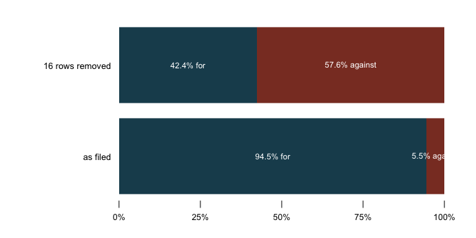

The opposing total is identical in both bars ($2.73 billion). It is the supporting total that collapses, from $46.94 billion to $2.02 billion.

As filed, the file says outside spending was **94.5% supportive** — $46.94 billion for candidates against $2.73 billion opposing them. That is a finding. It is the kind of sentence that appears in a news story about the positivity of a campaign. Remove 16 rows and the same file says outside spending was **57.6% opposing**. The junk does not inflate the total and leave the shape intact. **It reverses the conclusion.**

| Spender | On behalf of | Amount |
| --- | --- | --- |
| THE COURT OF DIVINE JUSTICE | AKHLAGHY, NADER | $9,978,412,568 |
| THE COMMITTEE OF 300 | AKHLAGHY, NADER | $9,778,412,568 |
| THE COMMITTEE OF 300 | AKHLAGHY, NADER | $9,000,000,000 |
| THE COMMITTEE OF 300 | AKHLAGHY, NADER | $7,959,594,848 |
| Republican Emo Girl | BOUNNHARAT, AMANDRA | $6,347,882,325 |
| The Masonic Illuminati Eye | AKHLAGHY, NADER | $ 579,874,829 |

Read the top row of that table as the FEC published it. The spender, the committee that says it paid, calls itself *THE COURT OF DIVINE JUSTICE*. The candidate it names is AKHLAGHY, NADER, who is not a national figure. The amount is $9,978,412,568, and the direction is coded S, for support. That single row is larger than everything the file holds once the junk is gone, $4.75 billion; all 16 rows together account for $44.93 billion.

Nothing about this is hidden or hard to find. It is in the official bulk download, published by the agency, in the same columns as every real transaction. The file is a faithful record of **what was filed**, which is exactly what a disclosure regime promises and is not the same thing as a record of what happened. The independent-expenditures chapter owns this file in depth: how the sixteen rows were found, and where the line sits between wrong and plausibly wrong.

## An average that describes nobody

The candidate file has the same character in a quieter way.

| Quantity | Value |
| --- | --- |
| Candidates in the file | 3,856 |
| Candidates who raised nothing at all | 986 |
| Mean receipts | $1,775,409 |
| Median receipts | $ 21,200 |
| Ratio of mean to median | 83.7× |
| Share of all money raised by the top 1% of candidates | 58.9% |
| Share raised by the top 10% | 87.3% |

Mean receipts — every candidate’s total added up and divided by the number of candidates — are $1,775,409. Median receipts — what the candidate in the middle raised, with half the field above and half below — are $21,200. The mean is **83.7 times** the median.

The reason is that the file contains everyone who filed, and filing is not the same as running a campaign. 986 of the 3,856 candidates, about a quarter, raised **nothing at all**. Meanwhile the top one per cent account for 58.9% of all money raised.

“The average candidate raised $1,775,409” is arithmetically correct and describes no one in the file. This is the book’s recurring denominator problem wearing a dollar sign. The denominator is the bottom number you divide by, and here it is the set of candidates being averaged over. That set was defined by an administrative act (who filed a form), and it is not the population anyone has in mind when they say “candidate.”

## What the regime does and does not require

| Filer | Must report | What stays invisible | Verified first |
| --- | --- | --- | --- |
| Candidate committee | Receipts, disbursements, and each contributor over the itemisation threshold | Contributions aggregating $200 or less – reported only as a lump sum | No |
| Political action committee | The same, plus contributions made to candidates | The same threshold applies | No |
| Super PAC (independent-expenditure-only committee) | Receipts and independent expenditures, including donors | Nothing about coordination, which is a legal question the data cannot answer | No |
| Party committee | Receipts, disbursements, and coordinated spending | The line between coordinated and independent spending | No |
| 501(c)(4) social welfare organisation | Independent expenditures only, if it makes them | Its donors – who need not be disclosed at all | No |

Three boundaries are worth naming, because each one makes something structurally unobservable rather than merely unreported.

**The itemisation threshold.** Contributions from a person aggregating $200 or less in a cycle are not itemised. Small donors exist in the file only as a lump sum. So *how many people gave to this campaign* cannot be answered from the itemised records, and the itemised records are what everybody uses.

**Donor disclosure for 501(c)(4) organisations.** A nonprofit organised under section 501(c)(4) of the tax code — the “social welfare” category, which may do some political work without registering as a committee — reports its independent expenditures and need not report who funded it.[^7] The money appears; its origin does not.

**Coordination.** Whether spending was coordinated with a campaign is a *legal question*, decided after the fact if at all. It is not a field. A file that separates “independent” from “coordinated” spending is reporting a filer’s characterisation, not an established fact.

Notice what the three boundaries share. None is a gap in coverage that better collection would close. Each is a line the law drew on purpose, and what falls outside the line is invisible in the same way a survey’s unasked question is invisible.

## The lobbying registry is the parallel record

Campaign finance is not the only file its subjects write. Lobbying disclosure works the same way under a different statute, the Lobbying Disclosure Act of 1995:[^8] firms and organisations that lobby Congress file a quarterly report, the LD-2, naming their clients, roughly what they were paid, and the issues. The filings are published by the Secretary of the Senate and the Clerk of the House, searchable by anyone at https://lda.senate.gov/system/public/, and unverified, exactly like the FEC’s.

The parallel runs deep enough to be useful. Both regimes record self-reported money attached to named political actors. Both have thresholds beneath which activity legally vanishes. And both were built to expose, not to measure — the lobbying chapter reads one quarter of the registry and finds the two things the form was built not to record. If you understand why an FEC total needs checking before quoting, you already understand the lobbying file.

## What this data cannot tell you

**Nothing here is evidence of fraud, and the sixteen rows are almost certainly not a scheme.** They look like what they probably are: nonsense filings, or a filer’s error, sitting unremarked in an unverified system. The lesson is not that someone tried to deceive anybody. It is that a system which publishes what it receives will publish whatever it receives, and the reader is the only quality control there is.

This chapter also does not measure **influence**. The file records money moved between entities. What that money bought is not in it: access, attention, a changed vote, or nothing at all. No amount of transaction detail gets there, and the lobbying registry stops at the same wall.

The figures are one cycle, 2024, and federal only. State campaign finance is fifty more regimes with fifty more thresholds, and the boundaries described here are federal ones.

Finally, a word in the FEC’s defence, because the chapter has been hard on the file. Disclosure was the reform. Before the Federal Election Campaign Act the obligation existed mostly on paper: the Federal Corrupt Practices Act of 1925 asked for reports, and was so full of gaps and so rarely enforced that nobody could say who paid for a campaign.[^9] That anyone can now download every itemised contribution in a federal election is an achievement of transparency law, not a failure of it. That the resulting file requires care is the price of it being public quickly and without a gatekeeper deciding what is fit to publish. **A slower, cleaner, verified file would be a different and less democratic instrument.**

## What you should have learned

- Campaign finance data is self-reported under disclosure law: the subject of the record writes the record, the FEC publishes it unverified, and a filing is evidence of what somebody said on a form, not of what happened.
- Junk survives publication, and it can do more than inflate: removing 16 rows moves the 2024 independent-expenditure file from 94.5% supportive to 57.6% opposing — the conclusion reverses.
- The file’s population is an administrative artifact. 986 of 3,856 filed candidates raised nothing, so mean receipts run 83.7 times the median and describe nobody.
- The regime’s thresholds make some questions structurally unanswerable: donors at $200 or less are a lump sum, 501(c)(4) funders go unnamed, and “independent” is a filer’s claim rather than a fact.
- Candidates, committees and outside groups are different entities in law and in the files, and the lobbying registry is the same kind of self-written record under a different statute.

## Where this data appears in this book

- Reading an FEC Candidate Filing — the candidate summary file itself, and the single letter beside each candidate’s name.
- Two Charts That Hide Their Own Data — one FEC file drawn as a pie and as a radar, and what each shape does to it.
- Junk Filings in FEC Independent Expenditures — the sixteen rows above, found and weighed, and the difference between wrong and plausibly wrong.
- Reading a Lobbying Disclosure Filing — the parallel self-written record, and the two things the form was built not to record.
- Campaign Money as a Network — the FEC publishes edges, and leaves you to decide what the nodes are.

## Sources

**Data**

- Federal Election Commission. *Independent Expenditure* bulk file, 2024 cycle, via this book’s independent-expenditures chapter. https://www.fec.gov/data/browse-data/?tab=bulk-data
- Federal Election Commission. *All Candidates* bulk file (`weball24`), 2024 cycle, via this book’s campaign-finance chapter. https://www.fec.gov/data/browse-data/?tab=bulk-data
- Federal Election Campaign Act of 1971, as amended, 52 U.S.C. §30101 et seq. https://www.law.cornell.edu/uscode/text/52/30101
- Lobbying Disclosure Act filings, U.S. Senate and Clerk of the House. https://lda.senate.gov/system/public/ and https://disclosurespreview.house.gov/
- Lobbying Disclosure Act of 1995, as amended, 2 U.S.C. §1601 et seq. https://www.law.cornell.edu/uscode/text/2/1601
- Federal Election Commission, “Mission and history.” https://www.fec.gov/about/mission-and-history/
- *Citizens United v. Federal Election Commission*, 558 U.S. 310 (2010). https://www.law.cornell.edu/supremecourt/text/08-205
- *SpeechNow.org v. FEC*, 599 F.3d 686 (D.C. Cir. 2010). https://www.govinfo.gov/app/details/USCOURTS-caDC-08-05223
- La Raja, Raymond J. and Brian F. Schaffner (2015). *Campaign Finance and Political Polarization: When Purists Prevail.* University of Michigan Press. https://press.umich.edu/Books/C/Campaign-Finance-and-Political-Polarization2

**The data itself**

Every figure above is drawn from these tables. They are plain CSV, they open in a spreadsheet, and they are yours to take further.

`distribution.csv`, `filed.csv`, `outliers.csv`, `regime.csv`

**Your turn**

None of these is answered above, and every one can be answered from the tables you just opened.

- `outliers.csv` holds filings with implausible values in `amount`. Read a few. Nobody checked these before publication — work out what that means for any total computed from the raw file.
- `filed.csv` shows the file as it arrives against what it means, in `pct_supporting` and `pct_opposing`. Which reading would a journalist publish by mistake?
- `regime.csv` says who must report and `what_is_invisible`. List the money that never appears in this file at all. How much of campaign finance is being disclosed?
- `distribution.csv` summarises the spread of candidate receipts in `quantity` and `value`. Find a summary statistic in it that would mislead somebody, and say who it would mislead.
[^1]: The Federal Election Campaign Act, 52 U.S.C. §30101 and following; the duty to report is §30104: https://www.law.cornell.edu/uscode/text/52/30104.
[^2]: The agency’s own account of that history: https://www.fec.gov/about/mission-and-history/.
[^3]: 52 U.S.C. §30104(b)(3)(A): each person whose contributions to a committee exceed $200 in the cycle is identified by name, address, occupation and employer: https://www.law.cornell.edu/uscode/text/52/30104.
[^4]: The layout of the candidate summary file, for example: https://www.fec.gov/campaign-finance-data/all-candidates-file-description/.
[^5]: 52 U.S.C. §30104(a) sets the quarterly and monthly schedules. §30104(g) requires independent expenditures of $1,000 or more in the last twenty days before an election to be reported within 24 hours, and of $10,000 or more earlier in the cycle within 48 hours: https://www.law.cornell.edu/uscode/text/52/30104.
[^6]: *Citizens United v. Federal Election Commission*, 558 U.S. 310 (2010): https://www.law.cornell.edu/supremecourt/text/08-205. *SpeechNow.org v. FEC*, 599 F.3d 686 (D.C. Cir. 2010): the opinion at https://www.govinfo.gov/app/details/USCOURTS-caDC-08-05223, and the FEC’s summary of the case at https://www.fec.gov/legal-resources/court-cases/speechnoworg-v-fec/.
[^7]: 26 U.S.C. §501(c)(4): https://www.law.cornell.edu/uscode/text/26/501.
[^8]: 2 U.S.C. §1601 and following; the quarterly report is §1604: https://www.law.cornell.edu/uscode/text/2/1604.
[^9]: The 1971 Act “consolidated its earlier reform efforts,” in the FEC’s words, and the 1974 amendments gave them an agency: https://www.fec.gov/about/mission-and-history/.